# Week 3 Peer Review

Following the directions on the Coursera assignment page, you will make four original visualizations. Note that the data for the CCES and CEL data are imported in code in the R Markdown file.

### Requirements

Using ggplot, create a scatter plot, a distribution figure (box plot, histogram, or density plot), bar plot, and line plot. Use colors and facetting in at least one of your figures. Add a text annotation to at least one of the your figures. Use a ggtheme for one of your figures. Make sure your figures have titles and appropriately labeled axes.

### Put your name here: Rocco Incardona

## Exercise 1

Explain what you are visualizing here: Ideology vs percentage of votes won in the 115th LES.Democratic members of the congress are less conservative and they also managed to win elections with larger shares of votes. Manual colors are set for this figure.

Put your figure here:

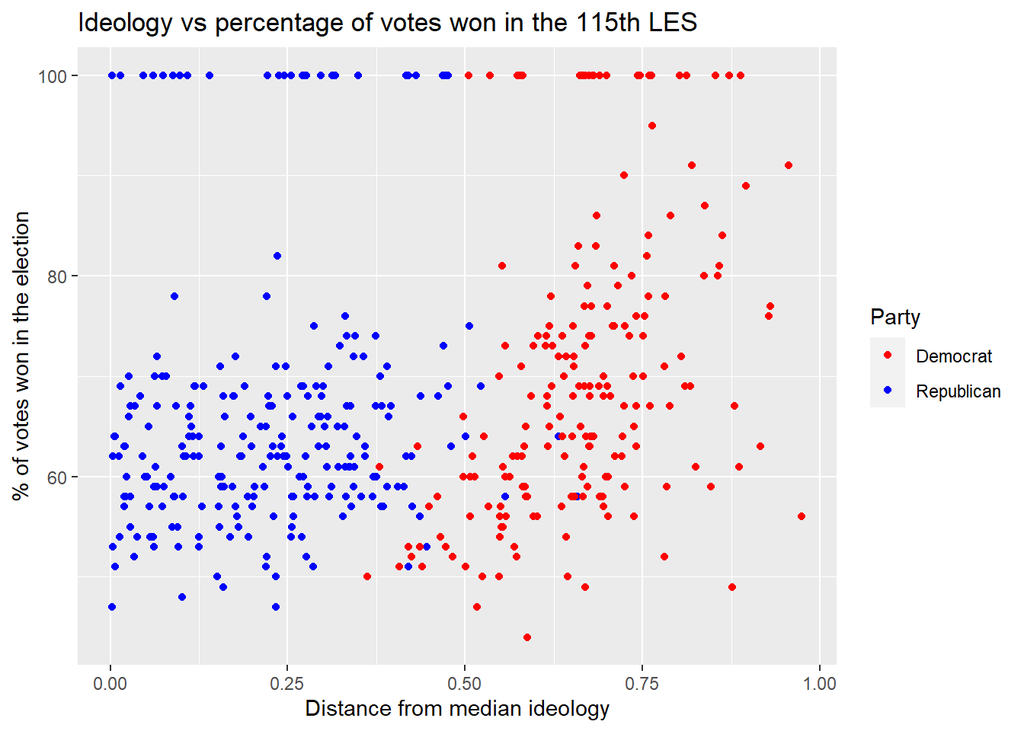

## Exercise 2

Explain what you are visualizing here: Family income by region and gender split. Female tend to have lower family income, especially in Northwest and West regions. Manual colors and facetting used in this chart.

Put your figure here:

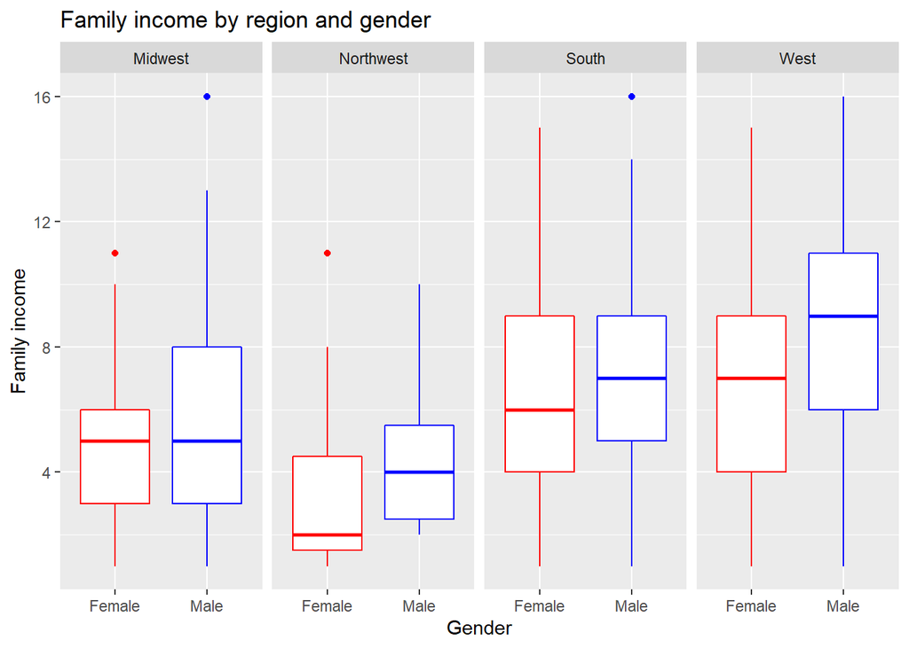

## Exercise 3

Explain what you are visualizing here: Religion importance by origin of the respondent. Respondents with hispanic origin tend to give higher importance to religion. ggtheme, manual colors and text annotations are used in this chart. Put your figure here:

```
## # A tibble: 8 x 4
## # Groups:   hispanic [2]
##   hispanic     pew_religimp               n ratio
##   <chr>        <chr>                  <int> <chr>
## 1 Hispanic     "Not at all important"     1 4.0%
## 2 Hispanic     "Not too important "       7 28.0%
## 3 Hispanic     "Somewhat important"       6 24.0%
## 4 Hispanic     "Very important"          11 44.0%
## 5 Not hispanic "Not at all important"   206 24.4%
## 6 Not hispanic "Not too important "     136 16.1%
## 7 Not hispanic "Somewhat important"     215 25.5%
## 8 Not hispanic "Very important"         287 34.0%
```

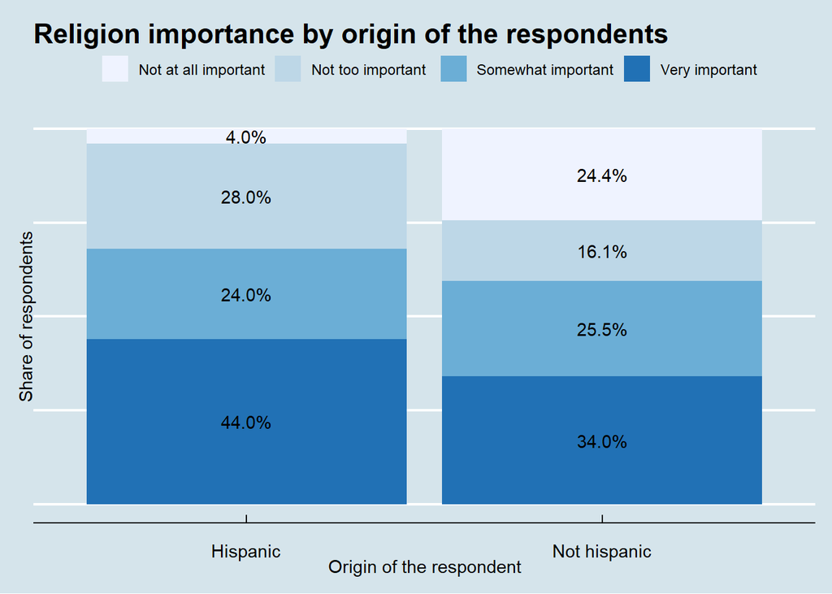

## Exercise 4

Explain what you are visualizing here: Revenues of three companies over time for one year. ggtheme and manual colors are used in this chart.

Put your figure here:

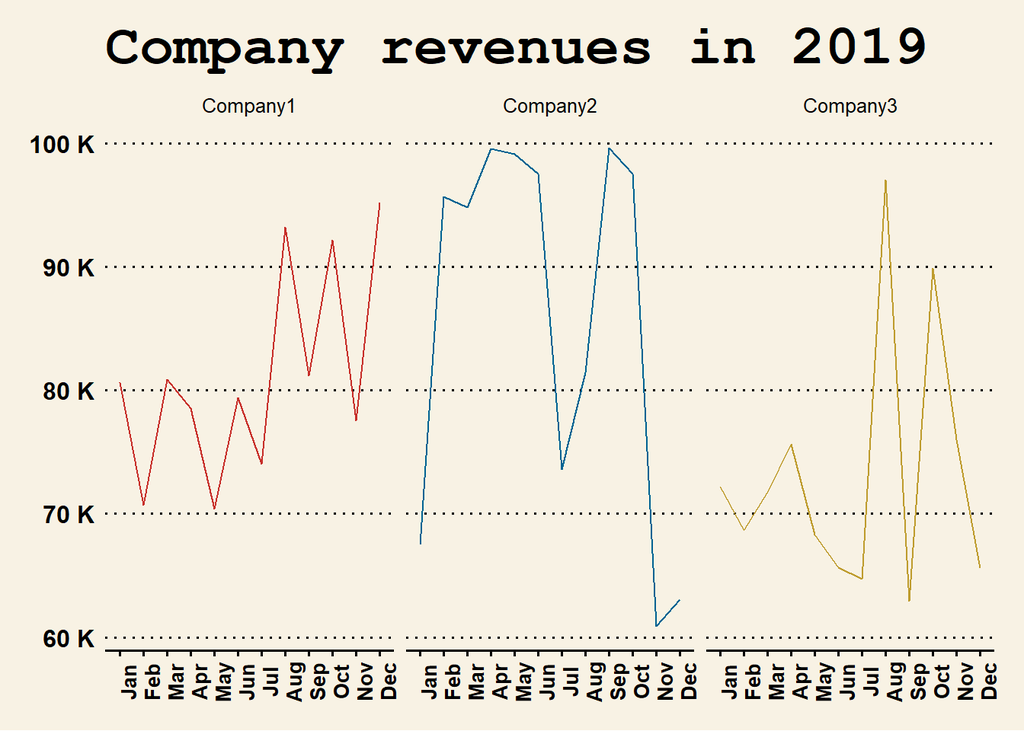